# Introduction of package ClusterR

## Introduction

ClusterR, as the name says, is an R package with some tools for clustering data.

Documentation can be found at https://cran.r-project.org/web/packages/ClusterR/.

## Summary

- Introduzione al clustering
- Descrizione dei tipi di clustering
  - Connectivity based
  - Centroid based
  - Distribution based
  - Density based
- Dataset di esempio della libreria
- Silouhette plot
- Clustering supportati da ClusterR
  - Centroid based
    - KMeans_rcpp
    - KMeans_arma
    - mini-batch KMeans
    - Optimal_Clusters_KMeans
  - Mediod based
    - Cluster_Medoids
    - Clara_Medoids
  - Distribution based clustering
    - Gaussian Mixture Models
      - Optimal_Clusters_GMM
- Distribution vs Centroid
- differenze clustering usando i dataset sintetici
- external_validation per validazione con true label
- (optional) paragone ClusteR vs ClusterR

## Unsupervised Learning

Clustering data is a technique used in the unsupervised learning framework, where for each observation $1 \leq i \leq n$, is given only the vector $x_i$ of the measurements, without any associated response variable $y_i$.

So, since we do not have $y$ we cannot apply any type of checks on the error between real and predicted values for the response variable.

## Clustering

Clustering is the task of dividing the population or data points into a number of groups such that data points in the same groups are more similar to other data points in the same group and dissimilar to the data points in other groups. It is basically a collection of objects on the basis of similarity and dissimilarity between them.

Clustering is one of the unsupervised learning methods: it means that we have no references or labeled responses. For this reason the clustering algorithms can only rely on the given data, regardless of the specific task we are trying to solve. Clustering is suitable for explaining the possible data-generating process, for finding possible relations or hierarchies between data or as a part of the exploratory data analysis.

For doing clustering is necessary to define a measure of similarity: similar items should belong to the same group. A measure of similarity must be non-negative, symmetric and must have a value of zero only if the items are equal. There are various possible similarity measures, for example: euclidean distance, manhattan distance and maximum distance. A clustering library should give the possibility to specify the similarity function to be used.

A predictive algorithm based on clustering may for example use the value of nearest cluster to give the response for a new data point. It is also possible to combine the informations of all clusters, weighted by the cluster distances.

There are four different types of clustering: - Connectivity based - Centroid based - Distribution based - Density based

Connectivity-based clustering tries to create connections between the clusters. In this way the algorithm creates a tree (or a forest), which can give us an hierarchial view of the data. Two possible uses can be creating a cause-effect relationship between items or reconstructing a possible evolution of a population.

Centroid-based clustering is based on centroids: each item belongs to the class of its nearest centroid. The centroids can be restricted to locations of the items (medoid) or generic points (centroid). The number of centroids can be hard-coded or searched by the algorithm; the position of the centroids is optimized by the algorithm. In general it is better to have the minimum number of centroids that explains well the data (simplest model).

Distribution-based clustering uses a probabilistic model to explain the original data-generating model, by minimizing the discrepancy. By doing so, it is possible to create specific models that accurately describe the data and give an idea of the prediction confidence. A general way to describe data is by using Gaussian Mixture Models.

Density-based clustering groups data using distance between points. Dense connected regions of points should be part of the same cluster. In this way there is not a fixed number of clusters, but the number of clusters depends on how many different regions of data points are there and on the chosen density threshold. Two examples of density-based clustering algorithms are DBSCAN and OPTICS.

ClusterR is a package designed for cluster generation and analysis. It combines different clustering algorithms, along with helper functions and example datasets.

The package is subdivided in different parts: - clustering algorithms - searching for optimal number of clusters of the clustering algorithms - prediction using the generated clusters - visualization of the clustering goodness using 2d scatterplots and silouhette dissimilarity plots - validation of the clustering goodness using ground truth labels - helper methods

```r
ClusterR::center_scale
ClusterR::plot_2d

ClusterR::AP_affinity_propagation
ClusterR::AP_preferenceRange
ClusterR::cost_clusters_from_dissim_medoids
ClusterR::distance_matrix

ClusterR::external_validation

ClusterR::Clara_Medoids
ClusterR::Cluster_Medoids
ClusterR::GMM
ClusterR::KMeans_arma
ClusterR::KMeans_rcpp
ClusterR::MiniBatchKmeans

ClusterR::Optimal_Clusters_GMM
ClusterR::Optimal_Clusters_KMeans
ClusterR::Optimal_Clusters_Medoids

ClusterR::predict_GMM
ClusterR::predict_KMeans
ClusterR::predict_MBatchKMeans
ClusterR::predict_Medoids

ClusterR::Silhouette_Dissimilarity_Plot
```

ClusterR only supports Distribution-based and Centroid-based algorithms.

The only distribution-based algorithm in ClusterR is GMM (Gaussian Mixture Model). GMM models the data-generating process as a set of gaussian models, one for each cluster. Doing so, each gaussian (cluster) gives the probability density function of the points it generates. A point belongs to the cluster that maximized the probability of generating it there.

GMM uses generalized gaussian distributions, so each cluster has its own independent mean (centroid) and variance (diagonal covariance matrix).

For the Centroid-based algorithms, ClusterR supports K-means and K-medoids variations.

K-means initially creates k random points which represents the centroids. Then, for each iteration, the algorithm moves the centroid positions to optimize the clustering. The k-medoid algorithms is a variation of k-means, which changes the way to calculate the center of each cluster: - k-means uses the mean of all its points (which is not necessarily a point of the cluster) * pros: center of the cluster coincides with the mean point over all its coordinates - k-mediods uses the median point of the cluster (so a point of the cluster) * pros: center of the cluster coincides is not influenced by noise or outliers.

For testing the GMM algorithm, we have created a synthetic dataset drawn from three 2-dimensional gaussians.

To do it we used the library MASS, which defines the function mvrnorm: specifying the mu (mean) and sigma (correlation matrix), along with the desidered dimensionality and number of samples, it returns a matrix representing n R^k points. Then we combined three of these matrix (one for each gaussian generating process) into a single dataframe, where the column “color” specifies the class for each point.

We finally visualized the points using a 2-d colored scatterplot; the digits indicate the positions of the centroids.

```r
# load library MASS
library(MASS)
library(dplyr)
library(ClusterR)
load_factor = 100
ncol=2

coeff = log(base=10, load_factor)/2    #choose if augmenting distance when generating more points
#coeff = 1

# create bivariate normal distribution
df1 = bind_rows(list(
  data.frame(mvrnorm(n = 10 * load_factor, mu = c(5*coeff, 5*coeff), Sigma = matrix(c(1, -.6, 0, 1), ncol = 2)), color=1),
  data.frame(mvrnorm(n = 10 * load_factor, mu = c(0*coeff, 0*coeff), Sigma = matrix(c(.8, 0, 0, 4), ncol = 2)), color=2),
  data.frame(mvrnorm(n = 15 * load_factor, mu = c(3*coeff, 1*coeff), Sigma = matrix(c(3, .7, 0, 2), ncol = 2)), color=3)
))

plot(x=df1$X1, y=df1$X2, col=df1$color)
points(c(5*coeff), c(5*coeff), pch="1", cex=2, col="brown")
```

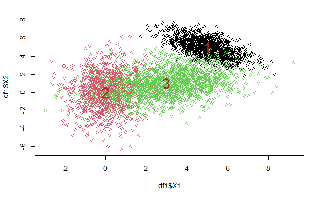

```r
points(c(0*coeff), c(0*coeff), pch="2", cex=2, col="brown")
points(c(3*coeff), c(1*coeff), pch="3", cex=2, col="brown")
```

The function given by the library to compute Gaussian Mixture Models (GMM) is GMM. It takes two compulsory arguments: the matrix specifying the item positions (one row for each item, one column for each component) and the number of gaussian processes.

[figure not shown]

It is also possible to use the *plot_2d* function, defined by by the ClusterR package, for a 2-d visualization of the predicted points along with the centroid/medoid positions.

The arguments are: - data, 2-dimensional matrix specifying the item positions - clusters, a list specifying the class for each item (numeric vector) - centroids_medoids, the position of the centroids (or medoids)

[figure not shown]

The function *external_validation*, also defined in the ClusterR package, gives us the possibility to extract some useful metrics measuring the goodness of the fit. It requires only the predicted values and annotated values.

The arguments are: - true_labels: the annotated values - clusters: the predicted values - method for calculating the goodness (the value returned by the function. although the function shows all the measures in the log) - summary_stats: whether or not to print summary statistics like sensitivity and specificity

```r
external_validation(df1$color, df1$color_pred_3, summary_stats = T)
```

[output not shown]

The GMM object has 4 attributes: - centroids: a matrix that specifies the position of one centroid per row - covariance_matrices: a matrix that specifies one diagonal covariance matrix per row - weights, for each gaussian component (list) - Log_likelihood: a matrix one row for each training item and one column for each component

```r
gmm_3$centroids
gmm_3$covariance_matrices
gmm_3$weights
head(gmm_3$Log_likelihood)
```

[output not shown]

Since it is possible to specify the number of clusters, we tried running the GMM algorithm specifying gaussian_comps=2.

```r
x = subset(df1, select=c(X1, X2))
gmm_2 = GMM(x, 2, dist_mode = "maha_dist", seed_mode = "random_subset")

# predict centroids, covariance matrix and weights
df1["color_pred_2"] = predict(gmm_2, newdata = x)

plot(x=df1$X1, y=df1$X2, col=df1$color_pred_2 + 1)
points(c(5*coeff), c(5*coeff), pch="1", cex=2, col="black")
points(c(0*coeff), c(0*coeff), pch="2", cex=2, col="black")
points(c(3*coeff), c(1*coeff), pch="3", cex=2, col="black")
points(gmm_2$centroids, pch="X", cex=2, col="azure")

external_validation(df1$color, df1$color_pred_2, summary_stats = T)
```

[output not shown]

How to find the optimal number of centroids? Doing so by plotting the data with colors only works for small datasets representable in two dimensions. The function Optimal_Clusters_GMM calculates the goodness of the fit for each # of clusters between 1 and max_clusters.

The criterion can be AIC (Alkaine Information Criterion) or BIC (Bayes Information Criterion). A rule of thumb is that we should select the smallest (simplest) model with good performances, so the best model should be the one which minimized one of these criterions.

```r
x = subset(df1, select=c(X1, X2))
opt_gmm = Optimal_Clusters_GMM(x, max_clusters = 10, criterion = "BIC",
                               dist_mode = "eucl_dist", seed_mode = "random_subset",
                               plot_data = T)
```

[output not shown]

ClusterR supports k-means algorithm with two different implementations: KMeans_arma and KMeans_rcpp. The difference is that KMeans_rcpp: - allows for the specification of the initial centroid positions and other initialization methods - the running time and convergence can be set by the user - the num_init parameter KMeans_arma is faster than KMeans_rcpp.

Their interface is similar to GMM, but specific for k-means task. The arguments for KMeans_rcpp are: - data: a matrix specifying the item positions (items on rows, components on columns) - clusters: the number of clusters - num_init: how many times to run the algorithm with different initializations. If >1, the function returns the best clustering by within-cluster-sum-of-squared-error - max_iters: max number of iterations - initializer: how to initialize the centroids (optimal_init, quantile_init, kmeans++, random) - fuzzy: if true, the prediction probabilities are proportional to the distances to the centroids - CENTROIDS: a matrix specifying the initial positions (one row per centroid, one column per component) - tol: tolerance for convergence - tol_optimal_init: tolerance value when using the “optimal_init” initializer (higher means further inital positions) - seed of the RNG (for reproducibility) - verbosity

In the following the result of k-means clustering with k=3 and KMeans_rcpp implementation.

```r
help(KMeans_arma)

x = subset(df1, select=c(X1, X2))
kmeans_rcpp = KMeans_rcpp(x, 3)

# predict centroids, covariance matrix and weights
df1["color_pred_kmeans_3"] = predict(kmeans_rcpp, newdata = x)

plot(x=df1$X1, y=df1$X2, col=df1$color_pred_kmeans_3 + 1)
points(c(5*coeff), c(5*coeff), pch="1", cex=2, col="black")
points(c(0*coeff), c(0*coeff), pch="2", cex=2, col="black")
points(c(3*coeff), c(1*coeff), pch="3", cex=2, col="black")
points(kmeans_rcpp$centroids, pch="X", cex=2, col="azure")
```

[output not shown]

The k-medoid variations are supported by the implementations Cluster_Medoids and Clara_Medoids.

```r
x = subset(df1, select=c(X1, X2))
cluster_med = Cluster_Medoids(x, 3)

# predict centroids, covariance matrix and weights
df1["color_pred_cluster_3"] = predict(cluster_med, newdata = x)

plot(x=df1$X1, y=df1$X2, col=df1$color_pred_cluster_3 + 1)
points(c(5*coeff), c(5*coeff), pch="1", cex=2, col="black")
points(c(0*coeff), c(0*coeff), pch="2", cex=2, col="black")
points(c(3*coeff), c(1*coeff), pch="3", cex=2, col="black")
points(cluster_med$medoids, pch="X", cex=2, col="azure")
```

[output not shown]

```r
help(Silhouette_Dissimilarity_Plot)

data(soybean)

dat = soybean[, -ncol(soybean)]

cm = Cluster_Medoids(dat, clusters = 5, distance_metric = 'jaccard_coefficient')

plt_sd = Silhouette_Dissimilarity_Plot(cm, silhouette = TRUE)
```

[output not shown]

In the package ClusterR there are 3 different datasets: - dietary_survey_IBS: Synthetic data using a dietary survey of patients with irritable bowel syndrome. - mushroom: The mushroom data - soybean: The soybean (large) data set from the UCI repository

*dietary_survey_IBS* contains synthetic data generated using the mean and standard deviation of data used in the paper “A dietary survey of patients with irritable bowel syndrome”.

```r
help(dietary_survey_IBS)
```

It contains 400 rows and 43 columns.

“class” is the target column. Its values are O and 1, with 0 meaning healty and 1 meaning IBS-positive.

The other 42 columns are numeric and can be used as predictors.

```r
dim(dietary_survey_IBS)

colnames(dietary_survey_IBS)

unique(dietary_survey_IBS$class)

head(dietary_survey_IBS)
```

[output not shown]

In the following a 2d PCA for the entire dataset: black for class 0 (healty) and red for class 1 (positive).

```r
pca_dat = stats::princomp(dietary_survey_IBS)$scores[, 1:2]
plot(pca_dat, col=dietary_survey_IBS$class + 1)
```

[output not shown]

*mushroom* includes descriptions of hypothetical samples corresponding to 23 species of gilled mushrooms in the Agaricus and Lepiota Family (pp. 500-525).

Each species can either be edible or poisonous. The Guide clearly states that there is no simple rule for determining the edibility of a mushroom; no rule like ‘leaflets three, let it be’ for Poisonous Oak and Ivy. For simplicity the unknown targets are marked as poisounous.

```r
help(mushroom)
```

It contains 8124 rows and 23 columns.

“class” is the target column. Its values are “p” and “e”, with “p” meaning poisounous (or unknown) and e meaning “edible”.

The other 22 columns contain one character each and can be used as predictors.

```r
dim(mushroom)

colnames(mushroom)

unique(mushroom$class)

head(mushroom)
```

[output not shown]

In the following a 2d PCA for the entire dataset: black for class 0 (edible) and red for class 1 (poisounous).

```r
X = mushroom[1:1000, -1]

y = as.numeric(mushroom[1:1000, 1])

gwd = FD::gowdis(X)

gwd_mat = as.matrix(gwd)

pca_dat = stats::princomp(gwd_mat)$scores[, 1:2]
plot(pca_dat, col=y)
```

[output not shown]

*soybean* contains a dataset about soybeans characteristics from UCI machine learning repository.

There are both categorical and ordinal values, encoded by integers. Missing values were imputated using the mice package.

```r
help(soybean)
```

It contains 307 rows and 36 columns.

“class” is the target column. Its values are “diaporthe-stem-canker”, “charcoal-rot”, “rhizoctonia-root-rot”, “phytophthora-rot”, “brown-stem-rot”, “powdery-mildew”, “downy-mildew”, “brown-spot”, “bacterial-blight”, “bacterial-pustule”, “purple-seed-stain”, “anthracnose”, “phyllosticta-leaf-spot”, “alternarialeaf-spot”, “frog-eye-leaf-spot”, “diaporthe-pod-&-stem-blight”, “cyst-nematode”, “2-4-d-injury” and “herbicide-injury”.

```r
dim(soybean)

colnames(soybean)

unique(soybean$class)

head(soybean)
```

[output not shown]

```r
X = soybean[, -1]

y = as.numeric(soybean[, 1])

gwd = FD::gowdis(X)

gwd_mat = as.matrix(gwd)

pca_dat = stats::princomp(gwd_mat)$scores[, 1:2]
plot(pca_dat, col=y)
```

[output not shown]